# DOT Traffic Speeds

## **About the data**

**There are over 49 million rows in this dataset.**

Though a csv is available for download, accessing the data of interest via the API is the better choice when exploring a subset.

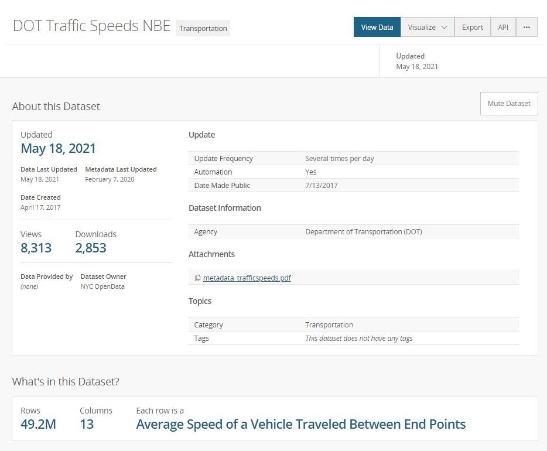

A useful [metadata doc](https://data.cityofnewyork.us/api/views/i4gi-tjb9/files/cc7f3b15-58b7-46e3-94e7-4c5753c3a8b8?download=true&filename=metadata_trafficspeeds.pdf) describes the purpose of this dataset:

*New York City DOT’s traffic speed detector feed is a free service that allows various user groups (i.e. the general public, private sector, commercial vendors, transportation agencies, researchers, media and others) to download traffic speed information on a regular basis to use in their applications and research efforts. This data feed contains 'real‐time' traffic information from locations where NYCDOT has installed sensors, mostly on major arterials and highways within the City limits. NYCDOT uses this information for emergency response and management.*

## **Read the data**

**I will demonstrate how to modify the "grab and go" API code into something that reads only a subset.**

DOT offers a helpful [API doc](https://dev.socrata.com/foundry/data.cityofnewyork.us/i4gi-tjb9) with "grab and go code" to read a subset into a pandas DataFrame.

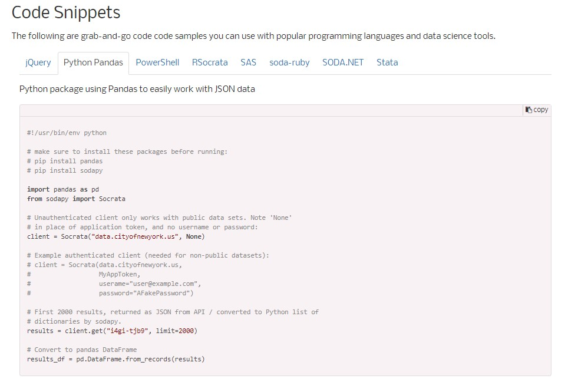

```python
# download libraries
import pandas as pd
from sodapy import Socrata
import matplotlib.pyplot as plt
```

```python
socrata_domain = "data.cityofnewyork.us"
socrata_dataset_identifier = "i4gi-tjb9"
socrata_token = "9vsY2bbNy0oJ7eHR3zEDwzL1c"
```

```python
# Unauthenticated client only works with public data sets. Note 'None'
# in place of application token, and no username or password:
# client = Socrata("data.cityofnewyork.us", None)

# Example authenticated client (needed for non-public datasets):
client = Socrata(socrata_domain, socrata_token, "snr131@gmail.com", "kULHSiw6TF2UjxN")

# First 20 results, returned as JSON from API / converted to Python list of
# dictionaries by sodapy.
results = client.get(dataset_identifier=socrata_dataset_identifier, limit=5)

# Convert to pandas DataFrame
results_df = pd.DataFrame.from_records(results)
```

```python
# display the first 5 results
results_df.head()
```

|  | id | speed | travel_time | status | data_as_of | link_id | link_points | encoded_poly_line | encoded_poly_line_lvls | owner | transcom_id | borough | link_name |
| --- | --- | --- | --- | --- | --- | --- | --- | --- | --- | --- | --- | --- | --- |
| 0 | 159 | 31.06 | 178 | 0 | 2021-05-17T19:44:10.000 | 4616252 | 40.8563506,-73.87233 40.85219,-73.871371 40.85... | ewjxF`e{aM~X_EfLs@pRFbE^fUlClPlC`TdE`Gb@\\\|HMt... | BBBBBBBBBBBBB | NYC_DOT_LIC | 4616252 | Bronx | BRP N WATSON AVENUE - FORDHAM ROAD |
| 1 | 184 | 52.81 | 48 | 0 | 2021-05-17T19:44:10.000 | 4616253 | 40.8347204,-73.86593 40.83357,-73.86199 40.832... | _pfxF`}yaMdFsWfDmPpH}^lEgTBBBBB | BBBBB | NYC_DOT_LIC | 4616253 | Bronx | CBE E TAYLOR AVENUE - CASTLE HILL AVENUE |
| 2 | 126 | 56.54 | 132 | 0 | 2021-05-17T19:44:10.000 | 4616247 | 40.8271606,-73.84993 40.82771,-73.84671 40.828... | w`exF~xvaMmBaSkCiSw@iLScPW}Hy@eH_BmHcDeIaIaO{D... | BBBBBBBBBBBBBBBBBBB | NYC_DOT_LIC | 4616247 | Bronx | BE N Castle Hill Avenue - Griswold Ave |
| 3 | 295 | 62.75 | 71 | 0 | 2021-05-17T19:44:10.000 | 4616250 | 40.84064,-73.83831 40.83881,-73.83853 40.83463... | _ugxFlptaMlJj@bY[rKeAdKgBdOgDnR}A | BBBBBBB | NYC_DOT_LIC | 4616250 | Bronx | HRP N LAFAYETTE AVENUE - E TREMONT AVENUE |
| 4 | 427 | 36.03 | 249 | 0 | 2021-05-17T19:44:10.000 | 4616259 | 40.7279205,-73.83298 40.7268904,-73.83239 40.7... | otqwFbosaMlEuBbBmA~BsC~CuF`CqDxBcC\\\|CgCbK{FnB... | BBBBBBBBBBBBBBBBBBBBBBBBBBB | NYC_DOT_LIC | 4616259 | Queens | VWE S MP6.39 (Exit 11 Jewel Ave) - MP4.63 (Exi... |

```python
# see column names and datatypes
results_df.info()
```

```
<class 'pandas.core.frame.DataFrame'>
RangeIndex: 5 entries, 0 to 4
Data columns (total 13 columns):
 #   Column                  Non-Null Count  Dtype
---  ------                  --------------  -----
 0   id                      5 non-null      object
 1   speed                   5 non-null      object
 2   travel_time             5 non-null      object
 3   status                  5 non-null      object
 4   data_as_of              5 non-null      object
 5   link_id                 5 non-null      object
 6   link_points             5 non-null      object
 7   encoded_poly_line       5 non-null      object
 8   encoded_poly_line_lvls  5 non-null      object
 9   owner                   5 non-null      object
 10  transcom_id             5 non-null      object
 11  borough                 5 non-null      object
 12  link_name               5 non-null      object
dtypes: object(13)
memory usage: 648.0+ bytes
```

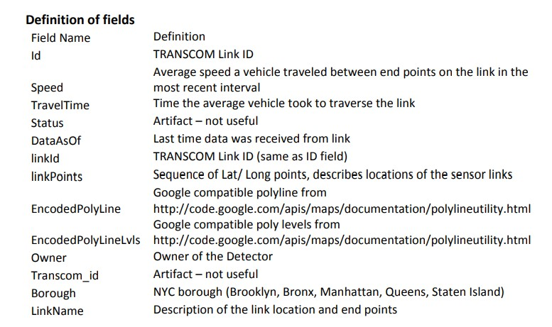

The sodapy.Socrata.client.get() method allows filtering of queries.

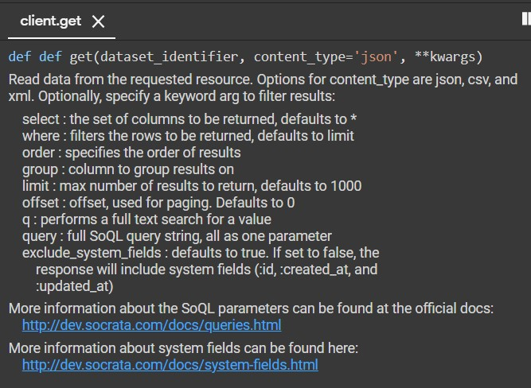

## Dataset challenge: size and cardinality

**The size of this dataset and the number of distinct values in each column presents a challenge when attempting to identify a subset. Prior to filtering this dataset, I received timeout errors. Before I attempt to create a pandas DataFrame from a subset, I will use sodapy to determine the number of distinct values in the link_name column.**

Like pandas, sodapy allows exploration of data.

```python
metadata = client.get_metadata(socrata_dataset_identifier)
[x['name'] for x in metadata['columns']]
```

```
['ID',
 'SPEED',
 'TRAVEL_TIME',
 'STATUS',
 'DATA_AS_OF',
 'LINK_ID',
 'LINK_POINTS',
 'ENCODED_POLY_LINE',
 'ENCODED_POLY_LINE_LVLS',
 'OWNER',
 'TRANSCOM_ID',
 'BOROUGH',
 'LINK_NAME']
```

There are 157 distinct link_values, i.e. traffic endpoints. See below.

```python
link_name_cardinality = [x for x in metadata['columns'] if x['name'] == 'LINK_NAME']
link_name_cardinality
```

```
[{'id': 298355225,
  'name': 'LINK_NAME',
  'dataTypeName': 'text',
  'fieldName': 'link_name',
  'position': 13,
  'renderTypeName': 'text',
  'tableColumnId': 46299007,
  'width': 208,
  'cachedContents': {'largest': 'WSE S VICTORY BOULEVARD - ARDEN AVENUE',
   'non_null': '49242167',
   'null': '0',
   'top': [{'item': 'CBE E TAYLOR AVENUE - CASTLE HILL AVENUE',
     'count': '364982'},
    {'item': '11th ave n ganservoort - 12th ave @ 40th st', 'count': '364980'},
    {'item': 'CBE W CASTLE HILL AVENUE - TAYLOR AVENUE', 'count': '364978'},
    {'item': 'BE N STRATFORD AVENUE - CASTLE HILL AVE', 'count': '364970'},
    {'item': 'CIP S Hempstead Tpk - Laurelton Pkwy @ SSP', 'count': '364958'},
    {'item': 'VWE S MP4.63 (Exit 6 Jamaica Ave) - MP2.66 (Exit 2 Roackaway Blvd)',
     'count': '364950'},
    {'item': 'Laurelton Pkwy N @ SSP - CIP N Hempstead Tpk',
     'count': '364938'},
    {'item': 'CIP S LIE - Hempstead Tpk', 'count': '364938'},
    {'item': 'LIE W 108TH ST - 84TH ST', 'count': '364930'},
    {'item': 'GOW N 92ND STREET - 7TH AVENUE', 'count': '364930'},
    {'item': '11th ave s ganservoort - west st @ spring st',
     'count': '364929'},
    {'item': 'VWE S MP6.39 (Exit 11 Jewel Ave) - MP4.63 (Exit 6 Jamaica Ave)',
     'count': '364928'},
    {'item': 'GOW N 7TH AVENUE - 9TH STREET', 'count': '364915'},
    {'item': '12th Ave N 40th - 57th St', 'count': '364913'},
    {'item': 'VWE N MP4.63 (Exit 6 - Jamaica Ave) - MP6.39 (Exit 11 Jewel Ave)',
     'count': '364912'},
    {'item': 'BKN Bridge Manhattan Side - FDR N Catherine Slip',
     'count': '364889'},
    {'item': 'BQE N Atlantic Ave - MAN Bridge Manhattan Side',
     'count': '364887'},
    {'item': 'GOW N 9TH STREET - ATLANTIC AVENUE', 'count': '364886'},
    {'item': 'Laurelton Pkwy S @ SSP - Belt Pkwy W 182nd St',
     'count': '364847'},
    {'item': 'BQE N LEONARD STREET - 46TH STREET', 'count': '364844'}],
   'not_null': '31745074',
   'smallest': '11th ave n ganservoort - 12th ave @ 40th st',
   'cardinality': '157'},
  'format': {}}]
```

I will use my app token to read a subset of data: the Cross Bronx Expressway beginning at E Taylor Avenue and ending at Castle Hill Avenue. I am requesting date in descending order so that I can see the 150,000 most recent records. I found that increasing the limit of records beyond this led to a timeout error. For reference, the Google Maps image below shows the length of the link, the distance in miles, and the approximate time to travel according to Google.

[figure not shown]

```python
client = Socrata(socrata_domain, socrata_token, "snr131@gmail.com", "kULHSiw6TF2UjxN")
results = client.get(dataset_identifier=socrata_dataset_identifier, limit=150000,
                     select="SPEED, TRAVEL_TIME, DATA_AS_OF, BOROUGH, LINK_NAME",
                     where="LINK_NAME == 'CBE E TAYLOR AVENUE - CASTLE HILL AVENUE'", order="DATA_AS_OF DESC")
```

```python
results_df = pd.DataFrame.from_records(results)
results_df.head()
```

|  | SPEED | TRAVEL_TIME | DATA_AS_OF | BOROUGH | LINK_NAME |
| --- | --- | --- | --- | --- | --- |
| 0 | 52.81 | 48 | 2021-05-17T19:44:10.000 | Bronx | CBE E TAYLOR AVENUE - CASTLE HILL AVENUE |
| 1 | 50.33 | 50 | 2021-05-17T19:39:10.000 | Bronx | CBE E TAYLOR AVENUE - CASTLE HILL AVENUE |
| 2 | 49.08 | 51 | 2021-05-17T19:34:10.000 | Bronx | CBE E TAYLOR AVENUE - CASTLE HILL AVENUE |
| 3 | 50.95 | 50 | 2021-05-17T19:29:10.000 | Bronx | CBE E TAYLOR AVENUE - CASTLE HILL AVENUE |
| 4 | 48.46 | 52 | 2021-05-17T19:24:10.000 | Bronx | CBE E TAYLOR AVENUE - CASTLE HILL AVENUE |

```python
print('This dataset begins on ', results_df['DATA_AS_OF'].min(), ' and ends on ', results_df['DATA_AS_OF'].max())
```

```
This dataset begins on  2019-09-01T16:18:10.000  and ends on  2021-05-17T19:44:10.000
```

## Clean and transform the data

```python
# convert a messy timestamp to a datetime object
from dateutil.parser import parse
results_df['DATA_AS_OF'] = results_df['DATA_AS_OF'].apply(parse)
```

```python
results_df.head()
```

|  | SPEED | TRAVEL_TIME | DATA_AS_OF | BOROUGH | LINK_NAME |
| --- | --- | --- | --- | --- | --- |
| 0 | 52.81 | 48 | 2021-05-17 19:44:10 | Bronx | CBE E TAYLOR AVENUE - CASTLE HILL AVENUE |
| 1 | 50.33 | 50 | 2021-05-17 19:39:10 | Bronx | CBE E TAYLOR AVENUE - CASTLE HILL AVENUE |
| 2 | 49.08 | 51 | 2021-05-17 19:34:10 | Bronx | CBE E TAYLOR AVENUE - CASTLE HILL AVENUE |
| 3 | 50.95 | 50 | 2021-05-17 19:29:10 | Bronx | CBE E TAYLOR AVENUE - CASTLE HILL AVENUE |
| 4 | 48.46 | 52 | 2021-05-17 19:24:10 | Bronx | CBE E TAYLOR AVENUE - CASTLE HILL AVENUE |

```python
# check the timestamp column datatype
from datetime import datetime
type(results_df['DATA_AS_OF'])
```

```
pandas.core.series.Series
```

```python
# split the timestamp into hour, month, day of week, and year
time = results_df['DATA_AS_OF']
results_df['HOUR'] = results_df['DATA_AS_OF'].apply(lambda time: time.hour)
results_df['DAY_OF_WEEK'] = results_df['DATA_AS_OF'].apply(lambda time: time.dayofweek)
results_df['MONTH'] = results_df['DATA_AS_OF'].apply(lambda time: time.month)
results_df['YEAR'] = results_df['DATA_AS_OF'].apply(lambda time: time.year)
```

```python
results_df.head()
```

|  | SPEED | TRAVEL_TIME | DATA_AS_OF | BOROUGH | LINK_NAME | HOUR | DAY_OF_WEEK | MONTH | YEAR |
| --- | --- | --- | --- | --- | --- | --- | --- | --- | --- |
| 0 | 52.81 | 48 | 2021-05-17 19:44:10 | Bronx | CBE E TAYLOR AVENUE - CASTLE HILL AVENUE | 19 | 0 | 5 | 2021 |
| 1 | 50.33 | 50 | 2021-05-17 19:39:10 | Bronx | CBE E TAYLOR AVENUE - CASTLE HILL AVENUE | 19 | 0 | 5 | 2021 |
| 2 | 49.08 | 51 | 2021-05-17 19:34:10 | Bronx | CBE E TAYLOR AVENUE - CASTLE HILL AVENUE | 19 | 0 | 5 | 2021 |
| 3 | 50.95 | 50 | 2021-05-17 19:29:10 | Bronx | CBE E TAYLOR AVENUE - CASTLE HILL AVENUE | 19 | 0 | 5 | 2021 |
| 4 | 48.46 | 52 | 2021-05-17 19:24:10 | Bronx | CBE E TAYLOR AVENUE - CASTLE HILL AVENUE | 19 | 0 | 5 | 2021 |

## EDA

### Speed

#### By hour

**Average speed looks as expected. With lowest average speed at around 4 or 5pm.**

```python
results_df["SPEED"] = pd.to_numeric(results_df["SPEED"])
results_df.groupby('HOUR')['SPEED'].mean()
```

```
HOUR
0     39.208625
1     38.944275
2     40.550813
3     42.940290
4     45.240950
5     47.483220
6     47.067433
7     45.261642
8     42.551894
9     41.505686
10    40.375983
11    38.283584
12    37.007093
13    36.614008
14    36.205019
15    35.537834
16    34.883566
17    34.947240
18    35.712110
19    37.388375
20    38.732030
21    39.852960
22    39.950647
23    39.725116
Name: SPEED, dtype: float64
```

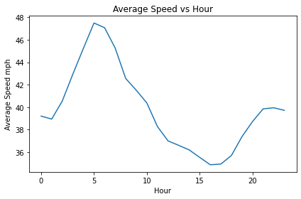

```python
results_df.groupby('HOUR').mean()['SPEED'].plot()
plt.xlabel("Hour")
plt.ylabel("Average Speed mph")
plt.title("Average Speed vs Hour")
plt.tight_layout()
```

#### By day of the week

**Unsurprisingly, traffic moves more slowly on the CBE on Fridays and fastest on Sundays.**

```python
results_df["SPEED"] = pd.to_numeric(results_df["SPEED"])
results_df.groupby('DAY_OF_WEEK')['SPEED'].mean()
```

```
DAY_OF_WEEK
0    40.027777
1    39.292556
2    39.284155
3    39.936136
4    38.203020
5    40.213160
6    41.841113
Name: SPEED, dtype: float64
```

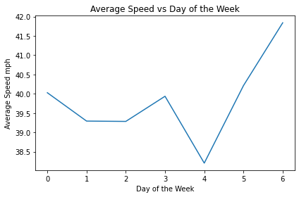

```python
results_df.groupby('DAY_OF_WEEK').mean()['SPEED'].plot()
plt.xlabel("Day of the Week")
plt.ylabel("Average Speed mph")
plt.title("Average Speed vs Day of the Week")
plt.tight_layout()
```

#### By month

**Average speed is lower in the summer months.**

```python
results_df["SPEED"] = pd.to_numeric(results_df["SPEED"])
results_df.groupby('MONTH')['SPEED'].mean()
```

```
MONTH
1     40.270911
2     36.727591
3     40.139607
4     40.947312
5     37.449329
6     37.380779
7     36.177175
8     36.244620
9     43.727521
10    42.019635
11    39.754677
12    40.614844
Name: SPEED, dtype: float64
```

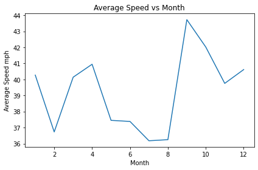

```python
results_df.groupby('MONTH').mean()['SPEED'].plot()
plt.xlabel("Month")
plt.ylabel("Average Speed mph")
plt.title("Average Speed vs Month")
plt.tight_layout()
```

#### By year

**Interestingly, traffic moved more slowly during 2020. I would have expected - with fewer commuters - for traffic to move more quickly during that time.**

```python
results_df["SPEED"] = pd.to_numeric(results_df["SPEED"])
results_df.groupby('YEAR')['SPEED'].mean()
```

```
YEAR
2019    40.973295
2020    38.789312
2021    41.546821
Name: SPEED, dtype: float64
```

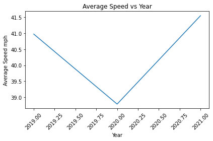

```python
results_df.groupby('YEAR').mean()['SPEED'].plot()
plt.xlabel("Year")
plt.ylabel("Average Speed mph")
plt.title("Average Speed vs Year")
plt.xticks(rotation=45)
plt.tight_layout()
```

### Travel time

#### By hour

```python
results_df["TRAVEL_TIME"] = pd.to_numeric(results_df["TRAVEL_TIME"])
results_df.groupby('HOUR')['TRAVEL_TIME'].mean()
```

```
HOUR
0      91.122387
1     100.830757
2     102.774808
3      88.698375
4      76.919771
5      64.560555
6      57.527407
7      59.225615
8      64.240013
9      65.765985
10     68.466052
11     73.240643
12     76.288136
13     75.244735
14     76.151868
15     76.552115
16     79.194687
17     78.347709
18     77.013664
19     72.864117
20     70.497244
21     73.394617
22     81.245376
23     86.451862
Name: TRAVEL_TIME, dtype: float64
```

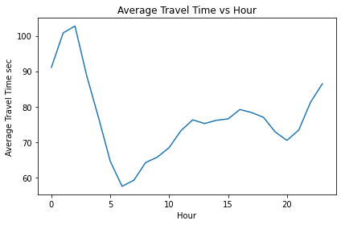

```python
results_df.groupby('HOUR').mean()['TRAVEL_TIME'].plot()
plt.xlabel("Hour")
plt.ylabel("Average Travel Time sec")
plt.title("Average Travel Time vs Hour")
plt.tight_layout()
```

#### By day of the week

**Unexpectedly, average travel time is shortest on Thursdays.**

```python
results_df["TRAVEL_TIME"] = pd.to_numeric(results_df["TRAVEL_TIME"])
results_df.groupby('DAY_OF_WEEK')['TRAVEL_TIME'].mean()
```

```
DAY_OF_WEEK
0    75.512959
1    77.966726
2    77.798285
3    73.548933
4    79.759433
5    75.963436
6    75.075102
Name: TRAVEL_TIME, dtype: float64
```

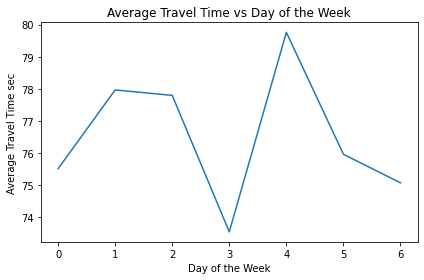

```python
results_df.groupby('DAY_OF_WEEK').mean()['TRAVEL_TIME'].plot()
plt.xlabel("Day of the Week")
plt.ylabel("Average Travel Time sec")
plt.title("Average Travel Time vs Day of the Week")
plt.tight_layout()
```

#### By month

```python
results_df["TRAVEL_TIME"] = pd.to_numeric(results_df["TRAVEL_TIME"])
results_df.groupby('MONTH')['TRAVEL_TIME'].mean()
```

```
MONTH
1     72.467042
2     84.886656
3     75.191074
4     80.434561
5     90.421453
6     81.140263
7     80.824985
8     81.663331
9     67.248887
10    68.302736
11    73.154779
12    73.263729
Name: TRAVEL_TIME, dtype: float64
```

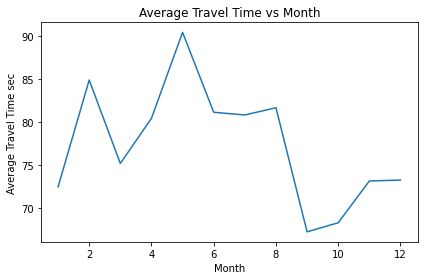

```python
results_df.groupby('MONTH').mean()['TRAVEL_TIME'].plot()
plt.xlabel("Month")
plt.ylabel("Average Travel Time sec")
plt.title("Average Travel Time vs Month")
plt.tight_layout()
```

#### By year

**Travel times are longer in 2020, which is expected as average speeds were lower.**

```python
results_df["TRAVEL_TIME"] = pd.to_numeric(results_df["TRAVEL_TIME"])
results_df.groupby('YEAR')['TRAVEL_TIME'].mean()
```

```
YEAR
2019    67.855934
2020    80.465667
2021    74.018260
Name: TRAVEL_TIME, dtype: float64
```

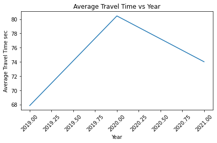

```python
results_df.groupby('YEAR').mean()['TRAVEL_TIME'].plot()
plt.xlabel("Year")
plt.ylabel("Average Travel Time sec")
plt.title("Average Travel Time vs Year")
plt.xticks(rotation=45)
plt.tight_layout()
```

## Predictive analysis using scikit-learn

```python
# import libraries
from sklearn.model_selection import train_test_split
from sklearn.linear_model import LinearRegression
```

### Split the data into training and testing sets

```python
dependent = results_df[['TRAVEL_TIME']]
independent_without_speed = results_df[['HOUR','DAY_OF_WEEK','MONTH']]
independent_with_speed = results_df[['HOUR','DAY_OF_WEEK','MONTH', 'SPEED']]
```

### Create and evaluate models

#### Without speed

```python
X_train, X_test, y_train, y_test = train_test_split(independent_without_speed, dependent, test_size=0.2, random_state=1)
```

```python
model = LinearRegression()
model.fit(X_train, y_train)
```

```
LinearRegression()
```

```python
model.score(X_train, y_train)
```

```
0.0025404256730651165
```

```python
model.score(X_test, y_test)
```

```
0.002540681244925569
```

#### With speed

```python
X_train, X_test, y_train, y_test = train_test_split(independent_with_speed, dependent, test_size=0.2, random_state=1)
```

```python
model = LinearRegression()
model.fit(X_train, y_train)
```

```
LinearRegression()
```

```python
model.score(X_train, y_train)
```

```
0.3660479518836093
```

```python
model.score(X_test, y_test)
```

```
0.3629112108300032
```